# 🗄️ Notebook 04 — SQL & SQLite Database

### Sales & Retail Analytics Portfolio Project

**Author:** Muhammad Umar Shahid **Email:** connect2umarshahid@gmail.com **GitHub:** github.com/Umar-Shahid/sales-retail-analytics

## 📋 What This Notebook Covers

| # | Topic | Description |
| --- | --- | --- |
| 1 | 🏗️ Database Design | Design a normalized schema from flat CSV |
| 2 | 📥 Data Loading | Load all processed data into SQLite tables |
| 3 | 🔍 Business Queries | Write 10+ real SQL queries answering business questions |
| 4 | 📊 Query Visualisation | Chart the results of key queries |
| 5 | 🔗 Python + SQL | Use pandas + sqlite3 together seamlessly |

## 🧠 Why SQL in a Data Science Portfolio?

> SQL is the **most requested skill** in data analyst and data science job postings — more than Python, more than Excel, more than any ML library.

Every business stores data in relational databases. Knowing SQL means you can:

- Extract data without asking an engineer
- Answer ad-hoc business questions in minutes
- Join data across tables that no single CSV contains
- Build the foundation for dashboards and reports

## 🗄️ Why SQLite?

| Feature | SQLite |
| --- | --- |
| Installation | Zero — built into Python |
| Setup | No server, no credentials |
| File-based | Entire database = one `.db` file |
| SQL standard | Fully compatible with PostgreSQL / MySQL syntax |
| Portfolio use | Perfect — shareable, reproducible, no dependencies |

> SQLite is used in production by Firefox, Android, WhatsApp, and Airbus. It is the most deployed database engine in the world.

## 📐 Database Schema We Will Build

```
┌─────────────┐     ┌──────────────┐     ┌─────────────┐
│  customers  │     │    orders    │     │  products   │
│─────────────│     │──────────────│     │─────────────│
│ customer_id │◄────│ customer_id  │     │ product_id  │
│ name        │     │ order_id  PK │────►│ name        │
│ segment     │     │ product_id   │     │ category    │
│ region      │     │ order_date   │     │ sub_category│
│ country     │     │ ship_date    │     └─────────────┘
└─────────────┘     │ ship_mode    │
                    │ sales        │     ┌─────────────┐
┌─────────────┐     │ quantity     │     │  rfm_segments│
│churn_scores │     │ discount     │     │─────────────│
│─────────────│     │ profit       │     │ customer_id │
│ customer_id │     └──────────────┘     │ recency     │
│ churn_proba │                          │ frequency   │
│ risk_tier   │                          │ monetary    │
└─────────────┘                          │ segment     │
                                         └─────────────┘
```

## 🔧 Section 0 — Setup & Database Connection

### Key Libraries

| Library | Role |
| --- | --- |
| `sqlite3` | Built-in Python library — no install needed. Creates and queries SQLite databases |
| `pandas` | Read CSVs, display query results as DataFrames |
| `matplotlib` / `seaborn` | Visualise query results |
| `os` | File path management |

### How sqlite3 Works

```
# Three core objects:
conn   = sqlite3.connect('mydb.db')  # Connection — opens/creates the database file
cursor = conn.cursor()               # Cursor — executes SQL statements
df     = pd.read_sql(query, conn)    # read_sql — runs query and returns DataFrame
```

### Two Ways to Run SQL in This Notebook

**Method 1 — cursor.execute()** → for CREATE, INSERT, UPDATE, DELETE

```
cursor.execute("CREATE TABLE IF NOT EXISTS customers (...)")
conn.commit()   # always commit after writing operations
```

**Method 2 — pd.read_sql()** → for SELECT queries

```
df = pd.read_sql("SELECT * FROM customers LIMIT 5", conn)
df  # displays as a nice DataFrame
```

> We use Method 1 for building the database and Method 2 for all business queries — best of both worlds.

```python
# ── Standard Library ──────────────────────────────────────────────────────────
import sqlite3
import os
import warnings

# ── Data Manipulation ─────────────────────────────────────────────────────────
import pandas as pd
import numpy as np

# ── Visualisation ─────────────────────────────────────────────────────────────
import matplotlib.pyplot as plt
import matplotlib.ticker as mticker
import seaborn as sns

# ── Config ────────────────────────────────────────────────────────────────────
warnings.filterwarnings('ignore')
pd.set_option('display.float_format', '{:.2f}'.format)
pd.set_option('display.max_columns', 40)

# ── Plot Style ────────────────────────────────────────────────────────────────
plt.rcParams.update({
    'figure.dpi':        150,
    'figure.facecolor':  'white',
    'axes.facecolor':    '#f8f9fa',
    'axes.grid':         True,
    'grid.alpha':        0.4,
    'axes.spines.top':   False,
    'axes.spines.right': False,
    'font.family':       'DejaVu Sans',
    'axes.titlesize':    13,
    'axes.labelsize':    11,
})

# ── Database Path ─────────────────────────────────────────────────────────────
# We store the .db file inside a dedicated folder
# One .db file = entire database (tables, indexes, data)
os.makedirs('../database', exist_ok=True)
DB_PATH = '../database/superstore.db'

# ── Create Connection ─────────────────────────────────────────────────────────
# sqlite3.connect() creates the file if it doesn't exist
# or opens it if it already does — safe to run multiple times

conn   = sqlite3.connect(DB_PATH)
cursor = conn.cursor()

# ── Enable Foreign Keys ───────────────────────────────────────────────────────
# SQLite has foreign key enforcement DISABLED by default
# This pragma turns it on for data integrity
cursor.execute("PRAGMA foreign_keys = ON")

print("✅ SQLite connection established")
print(f"   Database path : {os.path.abspath(DB_PATH)}")
print(f"   SQLite version: {sqlite3.sqlite_version}")
print(f"   Python sqlite3: v{sqlite3.version}")
```

```
✅ SQLite connection established
   Database path : c:\Users\umars\Downloads\sales-retail-analytics\database\superstore.db
   SQLite version: 3.45.1
   Python sqlite3: v2.6.0
```

## 📥 Section 1 — Load Source Data

### Strategy: CSV → pandas → SQLite

| Step | Action |
| --- | --- |
| 1 | Load CSVs into pandas DataFrames |
| 2 | Rename columns to SQL convention — lowercase, underscores, no special characters |
| 3 | Write each DataFrame into SQLite via `df.to_sql()` |

### SQL Naming Conventions

| Bad (CSV style) | Good (SQL style) |
| --- | --- |
| `Customer ID` | `customer_id` |
| `Order Date` | `order_date` |
| `Sub-Category` | `sub_category` |
| `Profit Margin %` | `profit_margin_pct` |

```python
# Load main dataset
df = pd.read_csv('../data/processed/superstore_clean.csv')
df['Order Date'] = pd.to_datetime(df['Order Date'], format='mixed', dayfirst=True)
df['Ship Date']  = pd.to_datetime(df['Ship Date'],  format='mixed', dayfirst=True)

# Load ML outputs from Notebook 03
rfm_df   = pd.read_csv('../data/processed/rfm_segments.csv')
churn_df = pd.read_csv('../data/processed/churn_risk_scores.csv')

print("=" * 50)
print("📂 SOURCE DATA LOADED")
print("=" * 50)
print(f"  Main dataset  : {df.shape[0]:,} rows × {df.shape[1]} cols")
print(f"  RFM segments  : {rfm_df.shape[0]:,} rows × {rfm_df.shape[1]} cols")
print(f"  Churn scores  : {churn_df.shape[0]:,} rows × {churn_df.shape[1]} cols")
print("=" * 50)
```

```
==================================================
📂 SOURCE DATA LOADED
==================================================
  Main dataset  : 8,286 rows × 35 cols
  RFM segments  : 791 rows × 7 cols
  Churn scores  : 791 rows × 8 cols
==================================================
```

## 🏗️ Section 2 — Build Database Tables

### Table 1: `customers`

Stores one row per unique customer — personal info, segment, location. This is the **parent table** — orders will reference it via `customer_id`.

```python
# ── Build customers DataFrame ─────────────────────────────────────────────────
customers = df[[
    'Customer ID', 'Customer Name', 'Segment', 'Country', 'Region'
]].drop_duplicates(subset='Customer ID').copy()

# Rename to SQL convention
customers.columns = [
    'customer_id', 'customer_name', 'segment', 'country', 'region'
]

print(f"✅ customers table : {len(customers):,} unique customers")
print(customers.head(4).to_string(index=False))

# ── Write to SQLite ───────────────────────────────────────────────────────────
# to_sql() parameters:
#   name            → table name in the database
#   con             → our sqlite3 connection
#   if_exists       → 'replace' drops and recreates table each run
#                     'append' adds rows, 'fail' raises error if table exists
#   index=False     → don't write pandas row numbers as a column
#   dtype           → explicitly set column types in SQLite

customers.to_sql(
    name      = 'customers',
    con       = conn,
    if_exists = 'replace',
    index     = False,
    dtype     = {
        'customer_id'  : 'TEXT PRIMARY KEY',
        'customer_name': 'TEXT',
        'segment'      : 'TEXT',
        'country'      : 'TEXT',
        'region'       : 'TEXT',
    }
)
conn.commit()

# ── Verify ────────────────────────────────────────────────────────────────────
result = pd.read_sql("SELECT COUNT(*) AS total_customers FROM customers", conn)
print(f"\n✅ customers table written to SQLite")
print(f"   Rows in DB : {result['total_customers'][0]:,}")
```

```
✅ customers table : 791 unique customers
customer_id customer_name     segment       country  region
   CG-12520   Claire Gute    Consumer United States   South
   AA-10480  Andrew Allen    Consumer United States   South
   IM-15070  Irene Maddox    Consumer United States    West
   HP-14815 Harold Pawlan Home Office United States Central

✅ customers table written to SQLite
   Rows in DB : 791
```

### Table 2: `products`

Stores one row per unique product — name, category, sub-category. Referenced by the `orders` table via `product_id`.

```python
# ── Build products DataFrame ──────────────────────────────────────────────────
products = df[[
    'Product ID', 'Product Name', 'Category', 'Sub-Category'
]].drop_duplicates(subset='Product ID').copy()

# Rename to SQL convention
products.columns = [
    'product_id', 'product_name', 'category', 'sub_category'
]

print(f"✅ products table : {len(products):,} unique products")
print(products.head(4).to_string(index=False))

# ── Write to SQLite ───────────────────────────────────────────────────────────
products.to_sql(
    name      = 'products',
    con       = conn,
    if_exists = 'replace',
    index     = False,
    dtype     = {
        'product_id'  : 'TEXT PRIMARY KEY',
        'product_name': 'TEXT',
        'category'    : 'TEXT',
        'sub_category': 'TEXT',
    }
)
conn.commit()

# ── Verify ────────────────────────────────────────────────────────────────────
result = pd.read_sql("SELECT COUNT(*) AS total_products FROM products", conn)
print(f"\n✅ products table written to SQLite")
print(f"   Rows in DB : {result['total_products'][0]:,}")

# ── Category Breakdown ────────────────────────────────────────────────────────
cat_summary = pd.read_sql("""
    SELECT   category,
             COUNT(*) AS product_count
    FROM     products
    GROUP BY category
    ORDER BY product_count DESC
""", conn)
print(f"\n📦 Products by category:")
print(cat_summary.to_string(index=False))
```

```
✅ products table : 1,841 unique products
     product_id                                                product_name        category sub_category
FUR-BO-10001798                           Bush Somerset Collection Bookcase       Furniture    Bookcases
FUR-CH-10000454 Hon Deluxe Fabric Upholstered Stacking Chairs, Rounded Back       Furniture       Chairs
OFF-PA-10002365                                                  Xerox 1967 Office Supplies        Paper
OFF-BI-10003656                 Fellowes PB200 Plastic Comb Binding Machine Office Supplies      Binders

✅ products table written to SQLite
   Rows in DB : 1,841

📦 Products by category:
       category  product_count
Office Supplies           1074
     Technology            393
      Furniture            374
```

### Table 3: `orders`

The **central fact table** of our schema. Each row = one line item (one product in one order). Links to `customers` via `customer_id` and `products` via `product_id`.

This is the largest table — all 8,286 rows from the cleaned dataset.

```python
# ── Build orders DataFrame ────────────────────────────────────────────────────
orders = df[[
    'Order ID', 'Customer ID', 'Product ID',
    'Order Date', 'Ship Date', 'Ship Mode',
    'Sales', 'Quantity', 'Discount', 'Profit',
    'Ship Days', 'Order Year', 'Order Month',
    'Order Quarter', 'Season'
]].copy()

# Rename to SQL convention
orders.columns = [
    'order_id', 'customer_id', 'product_id',
    'order_date', 'ship_date', 'ship_mode',
    'sales', 'quantity', 'discount', 'profit',
    'ship_days', 'order_year', 'order_month',
    'order_quarter', 'season'
]

# Convert dates to string for SQLite storage
# SQLite has no native DATE type — we store as ISO format string YYYY-MM-DD
# This allows date comparison in SQL using string ordering which works
# correctly for ISO format dates
orders['order_date'] = orders['order_date'].dt.strftime('%Y-%m-%d')
orders['ship_date']  = orders['ship_date'].dt.strftime('%Y-%m-%d')

print(f"✅ orders table : {len(orders):,} rows")
print(orders.head(4).to_string(index=False))

# ── Write to SQLite ───────────────────────────────────────────────────────────
orders.to_sql(
    name      = 'orders',
    con       = conn,
    if_exists = 'replace',
    index     = False,
    dtype     = {
        'order_id'     : 'TEXT',
        'customer_id'  : 'TEXT',
        'product_id'   : 'TEXT',
        'order_date'   : 'TEXT',
        'ship_date'    : 'TEXT',
        'ship_mode'    : 'TEXT',
        'sales'        : 'REAL',
        'quantity'     : 'INTEGER',
        'discount'     : 'REAL',
        'profit'       : 'REAL',
        'ship_days'    : 'INTEGER',
        'order_year'   : 'INTEGER',
        'order_month'  : 'INTEGER',
        'order_quarter': 'INTEGER',
        'season'       : 'TEXT',
    }
)
conn.commit()

# ── Verify ────────────────────────────────────────────────────────────────────
result = pd.read_sql("""
    SELECT
        COUNT(*)              AS total_rows,
        COUNT(DISTINCT order_id)    AS unique_orders,
        COUNT(DISTINCT customer_id) AS unique_customers,
        COUNT(DISTINCT product_id)  AS unique_products,
        ROUND(SUM(sales), 2)        AS total_sales,
        ROUND(SUM(profit), 2)       AS total_profit
    FROM orders
""", conn)

print(f"\n✅ orders table written to SQLite")
print(result.to_string(index=False))
```

```
✅ orders table : 8,286 rows
      order_id customer_id      product_id order_date  ship_date      ship_mode  sales  quantity  discount  profit  ship_days  order_year  order_month  order_quarter season
CA-2016-152156    CG-12520 FUR-BO-10001798 2016-11-08 2016-11-11   Second Class 261.96         2      0.00   41.91         92        2016            8              3 Summer
CA-2016-152156    CG-12520 FUR-CH-10000454 2016-11-08 2016-11-11   Second Class 731.94         3      0.00  219.58         92        2016            8              3 Summer
CA-2017-114412    AA-10480 OFF-PA-10002365 2017-04-15 2017-04-20 Standard Class  15.55         3      0.20    5.44          5        2017            4              2 Spring
CA-2016-161389    IM-15070 OFF-BI-10003656 2016-12-05 2016-12-10 Standard Class 407.98         3      0.20  132.59        153        2016            5              2 Spring

✅ orders table written to SQLite
 total_rows  unique_orders  unique_customers  unique_products  total_sales  total_profit
       8286           4119               791             1841   1939399.61     249505.81
```

### Tables 4 & 5: `rfm_segments` and `churn_scores`

These tables store the ML outputs from Notebook 03.

- `rfm_segments` — one row per customer with RFM scores + segment label
- `churn_scores` — one row per customer with churn probability + risk tier

Joining these tables with `orders` lets us answer questions like:

> *"What is the total revenue from Champions vs Lost customers?"* *"Which region has the highest concentration of Critical Risk churners?"*

```python
# ── Build rfm_segments DataFrame ──────────────────────────────────────────────
rfm_clean = rfm_df[[
    'Customer ID', 'CustomerName',
    'Recency', 'Frequency', 'Monetary',
    'Cluster', 'Segment'
]].copy()

rfm_clean.columns = [
    'customer_id', 'customer_name',
    'recency', 'frequency', 'monetary',
    'cluster', 'segment'
]

# ── Write rfm_segments to SQLite ──────────────────────────────────────────────
rfm_clean.to_sql(
    name      = 'rfm_segments',
    con       = conn,
    if_exists = 'replace',
    index     = False,
    dtype     = {
        'customer_id'  : 'TEXT PRIMARY KEY',
        'customer_name': 'TEXT',
        'recency'      : 'REAL',
        'frequency'    : 'INTEGER',
        'monetary'     : 'REAL',
        'cluster'      : 'INTEGER',
        'segment'      : 'TEXT',
    }
)
conn.commit()
print(f"✅ rfm_segments table written : {len(rfm_clean):,} rows")

# ── Build churn_scores DataFrame ──────────────────────────────────────────────
churn_clean = churn_df[[
    'Customer ID', 'Customer Name',
    'Recency', 'Frequency', 'Monetary',
    'Churn_Proba', 'Risk_Tier'
]].copy()

churn_clean.columns = [
    'customer_id', 'customer_name',
    'recency', 'frequency', 'monetary',
    'churn_proba', 'risk_tier'
]

# ── Write churn_scores to SQLite ──────────────────────────────────────────────
churn_clean.to_sql(
    name      = 'churn_scores',
    con       = conn,
    if_exists = 'replace',
    index     = False,
    dtype     = {
        'customer_id'  : 'TEXT PRIMARY KEY',
        'customer_name': 'TEXT',
        'recency'      : 'REAL',
        'frequency'    : 'INTEGER',
        'monetary'     : 'REAL',
        'churn_proba'  : 'REAL',
        'risk_tier'    : 'TEXT',
    }
)
conn.commit()
print(f"✅ churn_scores table written  : {len(churn_clean):,} rows")

# ── Verify All Tables Exist ───────────────────────────────────────────────────
tables = pd.read_sql("""
    SELECT name, type
    FROM   sqlite_master
    WHERE  type = 'table'
    ORDER BY name
""", conn)

print(f"\n{'='*40}")
print(f"🗄️  DATABASE TABLES")
print(f"{'='*40}")
for _, row in tables.iterrows():
    count = pd.read_sql(
        f"SELECT COUNT(*) AS n FROM {row['name']}", conn
    )['n'][0]
    print(f"  ✅ {row['name']:<20} {count:>6,} rows")
print(f"{'='*40}")
```

```
✅ rfm_segments table written : 791 rows
✅ churn_scores table written  : 791 rows

========================================
🗄️  DATABASE TABLES
========================================
  ✅ churn_scores            791 rows
  ✅ customers               791 rows
  ✅ orders                8,286 rows
  ✅ products              1,841 rows
  ✅ rfm_segments            791 rows
========================================
```

## 🔍 Section 3 — Business SQL Queries

We now write **10 real business queries** — the kind a data analyst would be asked to answer on their first week at a retail company.

| # | Question | SQL Concepts Used |
| --- | --- | --- |
| Q01 | Total sales & profit by year | GROUP BY, SUM, ROUND |
| Q02 | Top 10 most profitable products | ORDER BY, LIMIT |
| Q03 | Sales by category and region | GROUP BY multiple columns |
| Q04 | Average order value by segment | AVG, GROUP BY |
| Q05 | Monthly sales trend | strftime, GROUP BY |
| Q06 | Discount impact on profit | CASE WHEN, AVG |
| Q07 | Top 10 customers by revenue | JOIN, GROUP BY, ORDER BY |
| Q08 | Shipping mode performance | GROUP BY, AVG, COUNT |
| Q09 | RFM segment revenue contribution | JOIN across tables |
| Q10 | Critical churn risk by region | JOIN, WHERE, GROUP BY |

```
============================================================
📊 Q01 — Total Sales & Profit by Year
============================================================
 year  total_orders  total_sales  total_profit  profit_margin_pct
 2014           794    406360.22      41774.18              10.28
 2015           853    394211.40      48148.73              12.21
 2016          1084    509562.08      79583.29              15.62
 2017          1388    629265.92      79999.61              12.71
```

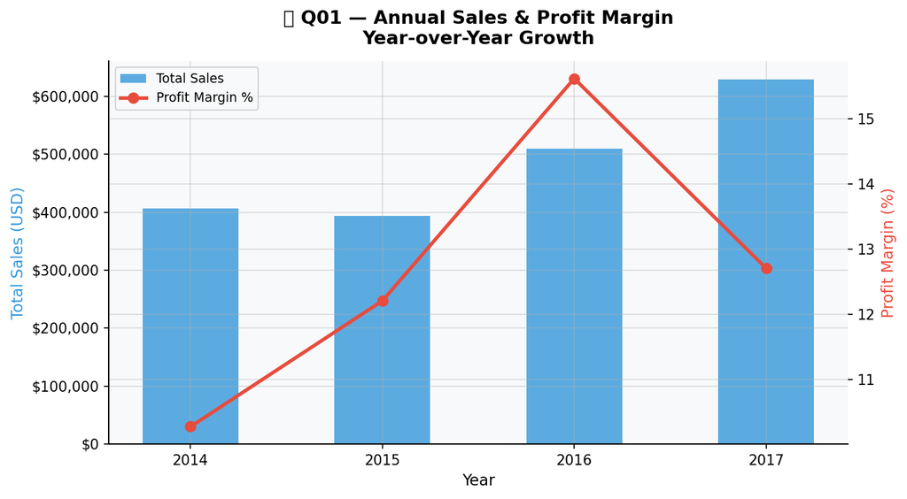

```
✅ Chart saved → reports/sql_q01_annual_sales.png
```

```python
# ── Q01: Total Sales & Profit by Year ─────────────────────────────────────────
# Business question: Is the business growing year over year?
# Concepts: GROUP BY, SUM, ROUND, ORDER BY
# ROUND(x, 2) → rounds to 2 decimal places
# We calculate profit margin as profit / sales * 100

q01 = pd.read_sql("""
    SELECT
        order_year                            AS year,
        COUNT(DISTINCT order_id)              AS total_orders,
        ROUND(SUM(sales), 2)                  AS total_sales,
        ROUND(SUM(profit), 2)                 AS total_profit,
        ROUND(SUM(profit) / SUM(sales) * 100, 2) AS profit_margin_pct
    FROM   orders
    GROUP BY order_year
    ORDER BY order_year
""", conn)

print("=" * 60)
print("📊 Q01 — Total Sales & Profit by Year")
print("=" * 60)
print(q01.to_string(index=False))

# ── Visualise Q01 ─────────────────────────────────────────────────────────────
fig, ax1 = plt.subplots(figsize=(9, 5))

x = q01['year'].astype(str)
bars = ax1.bar(x, q01['total_sales'],
               color='#3498db', alpha=0.8,
               label='Total Sales', width=0.5)

# Second y-axis for profit margin
ax2 = ax1.twinx()
ax2.plot(x, q01['profit_margin_pct'],
         color='#e74c3c', linewidth=2.5,
         marker='o', markersize=7,
         label='Profit Margin %')

ax1.set_title('📊 Q01 — Annual Sales & Profit Margin\nYear-over-Year Growth',
              fontweight='bold', pad=12)
ax1.set_xlabel('Year')
ax1.set_ylabel('Total Sales (USD)', color='#3498db')
ax2.set_ylabel('Profit Margin (%)', color='#e74c3c')
ax1.yaxis.set_major_formatter(
    mticker.FuncFormatter(lambda x, _: f'${x:,.0f}'))

lines1, labels1 = ax1.get_legend_handles_labels()
lines2, labels2 = ax2.get_legend_handles_labels()
ax1.legend(lines1 + lines2, labels1 + labels2,
           loc='upper left', fontsize=9)

plt.tight_layout()
plt.savefig('../reports/sql_q01_annual_sales.png',
            dpi=150, bbox_inches='tight')
plt.show()
print("✅ Chart saved → reports/sql_q01_annual_sales.png")
```

```
======================================================================
📊 Q02 — Top 10 Most Profitable Products
======================================================================
                                                               product_name        category sub_category  times_ordered  total_sales  total_profit  profit_margin_pct
                                      Canon imageCLASS 2200 Advanced Copier      Technology      Copiers              5     61599.82      25199.93              40.91
Fellowes PB500 Electric Punch Plastic Comb Binding Machine with Manual Bind Office Supplies      Binders              8     22877.82       6990.44              30.56
                                       Hewlett Packard LaserJet 3310 Copier      Technology      Copiers              7     15839.74       5543.91              35.00
                                         Canon PC1060 Personal Laser Copier      Technology      Copiers              4     11619.83       4570.93              39.34
                                  Logitech G19 Programmable Gaming Keyboard      Technology  Accessories             15     13756.54       4425.34              32.17
                  HP Designjet T520 Inkjet Large Format Printer - 24" Color      Technology     Machines              3     18374.90       4094.98              22.29
                                          Ativa V4110MDD Micro-Cut Shredder      Technology     Machines              2      7699.89       3772.95              49.00
                           3D Systems Cube Printer, 2nd Generation, Magenta      Technology     Machines              2     14299.89       3717.97              26.00
                                       Ibico EPK-21 Electric Binding System Office Supplies      Binders              3     15875.92       3345.28              21.07
                                          Zebra ZM400 Thermal Label Printer      Technology     Machines              2      6965.70       3343.54              48.00
```

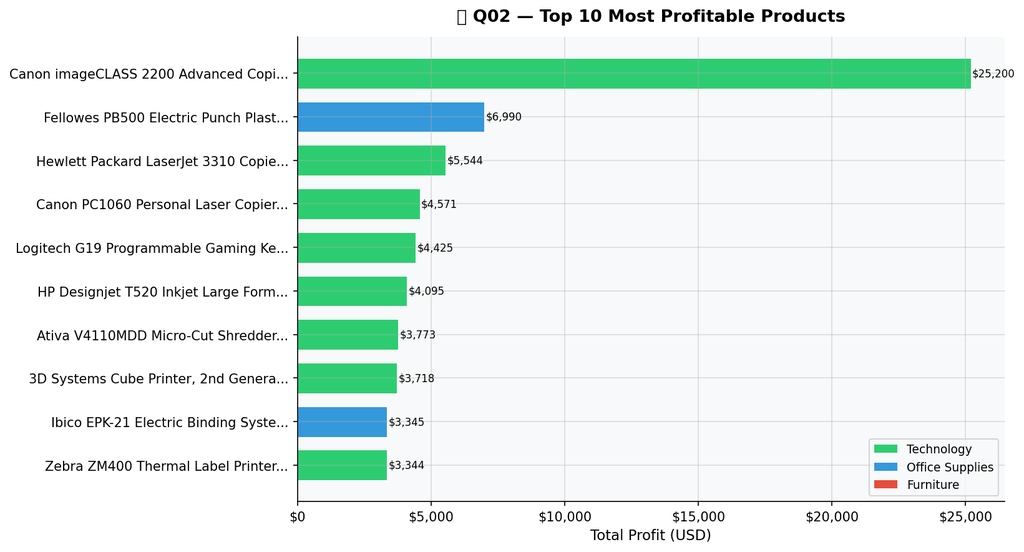

```
✅ Chart saved → reports/sql_q02_top_products.png
```

```python
# ── Q02: Top 10 Most Profitable Products ──────────────────────────────────────
# Business question: Which products should we promote most aggressively?
# Concepts: JOIN, GROUP BY, ORDER BY, LIMIT
# We JOIN orders with products to get product names and categories

q02 = pd.read_sql("""
    SELECT
        p.product_name,
        p.category,
        p.sub_category,
        COUNT(DISTINCT o.order_id)   AS times_ordered,
        ROUND(SUM(o.sales), 2)       AS total_sales,
        ROUND(SUM(o.profit), 2)      AS total_profit,
        ROUND(SUM(o.profit) /
              SUM(o.sales) * 100, 2) AS profit_margin_pct
    FROM   orders   o
    JOIN   products p ON o.product_id = p.product_id
    GROUP BY p.product_id
    ORDER BY total_profit DESC
    LIMIT  10
""", conn)

print("=" * 70)
print("📊 Q02 — Top 10 Most Profitable Products")
print("=" * 70)
print(q02.to_string(index=False))

# ── Visualise Q02 ─────────────────────────────────────────────────────────────
fig, ax = plt.subplots(figsize=(11, 6))

# Truncate long product names for display
q02['short_name'] = q02['product_name'].str[:35] + '...'

colors = ['#2ecc71' if c == 'Technology'
          else '#3498db' if c == 'Office Supplies'
          else '#e74c3c'
          for c in q02['category']]

ax.barh(
    q02['short_name'][::-1],
    q02['total_profit'][::-1],
    color=colors[::-1],
    edgecolor='white', linewidth=0.5,
    height=0.7
)

# Add value labels
for bar, val in zip(ax.patches, q02['total_profit'][::-1]):
    ax.text(
        bar.get_width() + 50,
        bar.get_y() + bar.get_height() / 2,
        f'${val:,.0f}',
        va='center', fontsize=8
    )

from matplotlib.patches import Patch
legend_elements = [
    Patch(facecolor='#2ecc71', label='Technology'),
    Patch(facecolor='#3498db', label='Office Supplies'),
    Patch(facecolor='#e74c3c', label='Furniture'),
]
ax.legend(handles=legend_elements, fontsize=9)
ax.set_title('📊 Q02 — Top 10 Most Profitable Products',
             fontweight='bold', pad=12)
ax.set_xlabel('Total Profit (USD)')
ax.xaxis.set_major_formatter(
    mticker.FuncFormatter(lambda x, _: f'${x:,.0f}'))
plt.tight_layout()
plt.savefig('../reports/sql_q02_top_products.png',
            dpi=150, bbox_inches='tight')
plt.show()
print("✅ Chart saved → reports/sql_q02_top_products.png")
```

```
=======================================================
📊 Q03 — Sales by Category and Region
=======================================================
 region        category  total_sales  total_profit
Central      Technology    196221.00      37725.97
Central       Furniture    162174.25       1704.34
Central Office Supplies    142975.45      23094.98
   East      Technology    195987.84      48050.20
   East Office Supplies    162412.02      29894.85
   East       Furniture    140623.03       1343.59
  South      Technology    135302.28      14945.56
  South Office Supplies    103273.71       9652.02
  South       Furniture     92578.60       6255.03
   West       Furniture    219320.08       7207.57
   West Office Supplies    199965.89      39125.58
   West      Technology    188565.46      30506.10
```

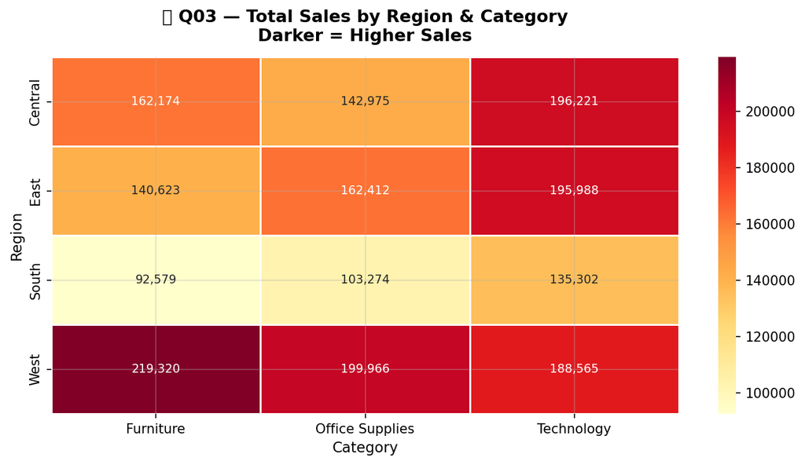

```
✅ Chart saved → reports/sql_q03_region_category.png
```

```python
# ── Q03: Sales by Category and Region ─────────────────────────────────────────
# Business question: Which category performs best in each region?
# Concepts: JOIN, GROUP BY multiple columns, pivot with pandas
# We use pandas pivot_table after the SQL query to reshape for heatmap

q03 = pd.read_sql("""
    SELECT
        c.region,
        p.category,
        ROUND(SUM(o.sales), 2)  AS total_sales,
        ROUND(SUM(o.profit), 2) AS total_profit
    FROM   orders   o
    JOIN   customers c ON o.customer_id = c.customer_id
    JOIN   products  p ON o.product_id  = p.product_id
    GROUP BY c.region, p.category
    ORDER BY c.region, total_sales DESC
""", conn)

print("=" * 55)
print("📊 Q03 — Sales by Category and Region")
print("=" * 55)
print(q03.to_string(index=False))

# ── Visualise Q03 as Heatmap ──────────────────────────────────────────────────
# Pivot: rows = region, columns = category, values = total_sales
pivot = q03.pivot_table(
    index='region', columns='category',
    values='total_sales', aggfunc='sum'
)

fig, ax = plt.subplots(figsize=(9, 5))
sns.heatmap(
    pivot, annot=True, fmt=',.0f',
    cmap='YlOrRd', ax=ax,
    linewidths=0.5, linecolor='white',
    annot_kws={'size': 9}
)
ax.set_title('📊 Q03 — Total Sales by Region & Category\n'
             'Darker = Higher Sales',
             fontweight='bold', pad=12)
ax.set_xlabel('Category')
ax.set_ylabel('Region')
plt.tight_layout()
plt.savefig('../reports/sql_q03_region_category.png',
            dpi=150, bbox_inches='tight')
plt.show()
print("✅ Chart saved → reports/sql_q03_region_category.png")
```

```
=================================================================
📊 Q04 — Performance by Customer Segment
=================================================================
    segment  total_orders  avg_line_item_value  total_sales  total_profit  profit_margin_pct
   Consumer          2123               226.24    974631.98     118767.61              12.19
  Corporate          1246               239.85    601073.84      77880.95              12.96
Home Office           750               247.07    363693.80      52857.25              14.53
```

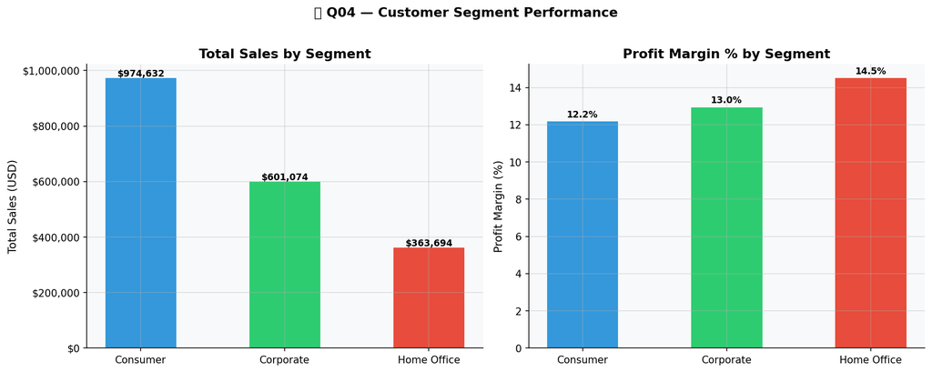

```
✅ Chart saved → reports/sql_q04_segment_performance.png
```

```python
# ── Q04: Average Order Value by Customer Segment ──────────────────────────────
# Business question: Which customer segment places the highest value orders?
# Concepts: JOIN, AVG, GROUP BY, HAVING
# AVG(sales) = average sales per line item
# We use a subquery to get average at ORDER level (not line item level)

q04 = pd.read_sql("""
    SELECT
        c.segment,
        COUNT(DISTINCT o.order_id)          AS total_orders,
        ROUND(AVG(o.sales), 2)              AS avg_line_item_value,
        ROUND(SUM(o.sales), 2)              AS total_sales,
        ROUND(SUM(o.profit), 2)             AS total_profit,
        ROUND(SUM(o.profit) /
              SUM(o.sales) * 100, 2)        AS profit_margin_pct
    FROM   orders   o
    JOIN   customers c ON o.customer_id = c.customer_id
    GROUP BY c.segment
    ORDER BY total_sales DESC
""", conn)

print("=" * 65)
print("📊 Q04 — Performance by Customer Segment")
print("=" * 65)
print(q04.to_string(index=False))

# ── Visualise Q04 ─────────────────────────────────────────────────────────────
fig, axes = plt.subplots(1, 2, figsize=(13, 5))

seg_colors = ['#3498db', '#2ecc71', '#e74c3c']

# Chart 1: Total Sales by Segment
axes[0].bar(
    q04['segment'], q04['total_sales'],
    color=seg_colors, edgecolor='white',
    linewidth=0.8, width=0.5
)
for bar, val in zip(axes[0].patches, q04['total_sales']):
    axes[0].text(
        bar.get_x() + bar.get_width() / 2,
        bar.get_height() + 5000,
        f'${val:,.0f}',
        ha='center', fontsize=9, fontweight='bold'
    )
axes[0].set_title('Total Sales by Segment', fontweight='bold')
axes[0].set_ylabel('Total Sales (USD)')
axes[0].yaxis.set_major_formatter(
    mticker.FuncFormatter(lambda x, _: f'${x:,.0f}'))

# Chart 2: Profit Margin by Segment
axes[1].bar(
    q04['segment'], q04['profit_margin_pct'],
    color=seg_colors, edgecolor='white',
    linewidth=0.8, width=0.5
)
for bar, val in zip(axes[1].patches, q04['profit_margin_pct']):
    axes[1].text(
        bar.get_x() + bar.get_width() / 2,
        bar.get_height() + 0.2,
        f'{val:.1f}%',
        ha='center', fontsize=9, fontweight='bold'
    )
axes[1].set_title('Profit Margin % by Segment', fontweight='bold')
axes[1].set_ylabel('Profit Margin (%)')

fig.suptitle('📊 Q04 — Customer Segment Performance',
             fontsize=13, fontweight='bold', y=1.02)
plt.tight_layout()
plt.savefig('../reports/sql_q04_segment_performance.png',
            dpi=150, bbox_inches='tight')
plt.show()
print("✅ Chart saved → reports/sql_q04_segment_performance.png")
```

```
============================================================
📊 Q05 — Monthly Sales Trend (all years)
============================================================
  Months covered : 48
  Best month     : 2017-11  ($98,495)
  Worst month    : 2014-02  ($2,291)
```

[figure not shown]

```
✅ Chart saved → reports/sql_q05_monthly_trend.png
```

```python
# ── Q05: Monthly Sales Trend ──────────────────────────────────────────────────
# Business question: What does the monthly sales pattern look like over 4 years?
# Concepts: strftime() — SQLite's date formatting function
# strftime('%Y-%m', order_date) extracts year-month e.g. '2011-01'
# This lets us group by month across all years

q05 = pd.read_sql("""
    SELECT
        strftime('%Y-%m', order_date)    AS year_month,
        order_year,
        order_month,
        COUNT(DISTINCT order_id)         AS total_orders,
        ROUND(SUM(sales), 2)             AS total_sales,
        ROUND(SUM(profit), 2)            AS total_profit
    FROM   orders
    GROUP BY year_month
    ORDER BY year_month
""", conn)

# Convert year_month to datetime for proper x-axis plotting
q05['date'] = pd.to_datetime(q05['year_month'], format='%Y-%m')

print("=" * 60)
print("📊 Q05 — Monthly Sales Trend (all years)")
print("=" * 60)
print(f"  Months covered : {len(q05)}")
print(f"  Best month     : {q05.loc[q05['total_sales'].idxmax(), 'year_month']}"
      f"  (${q05['total_sales'].max():,.0f})")
print(f"  Worst month    : {q05.loc[q05['total_sales'].idxmin(), 'year_month']}"
      f"  (${q05['total_sales'].min():,.0f})")

# ── Visualise Q05 ─────────────────────────────────────────────────────────────
fig, ax = plt.subplots(figsize=(14, 5))

ax.plot(
    q05['date'], q05['total_sales'],
    color='#2c3e50', linewidth=1.8,
    label='Monthly Sales'
)

# Shade area under line
ax.fill_between(
    q05['date'], q05['total_sales'],
    alpha=0.12, color='#3498db'
)

# Highlight Q4 each year (peak retail season)
for year in q05['order_year'].unique():
    q4_data = q05[(q05['order_year'] == year) &
                  (q05['order_month'].isin([10, 11, 12]))]
    if len(q4_data) > 0:
        ax.fill_between(
            q4_data['date'], q4_data['total_sales'],
            alpha=0.25, color='#e74c3c',
            label='Q4 (Oct–Dec)' if year == q05['order_year'].min() else ''
        )

ax.set_title('📊 Q05 — Monthly Sales Trend 2011–2014\n'
             'Red shading = Q4 peak retail season',
             fontweight='bold', pad=12)
ax.set_xlabel('Month')
ax.set_ylabel('Total Sales (USD)')
ax.yaxis.set_major_formatter(
    mticker.FuncFormatter(lambda x, _: f'${x:,.0f}'))
ax.legend(fontsize=9)
plt.tight_layout()
plt.savefig('../reports/sql_q05_monthly_trend.png',
            dpi=150, bbox_inches='tight')
plt.show()
print("✅ Chart saved → reports/sql_q05_monthly_trend.png")
```

```
======================================================================
📊 Q06 — Discount Impact on Profit
======================================================================
      discount_band  total_orders  avg_discount_pct  avg_sales  avg_profit  total_profit
1. No Discount (0%)          3944              0.00     233.68       69.70     274910.22
     2. Low (1-10%)            79             10.00     569.23       95.29       7528.23
 3. Medium (11-20%)          3082             19.90     217.18       25.86      79708.51
   4. High (21-40%)           378             34.60     502.33      -76.91     -29071.65
5. Very High (>40%)           803             70.20     141.45     -104.07     -83569.50
```

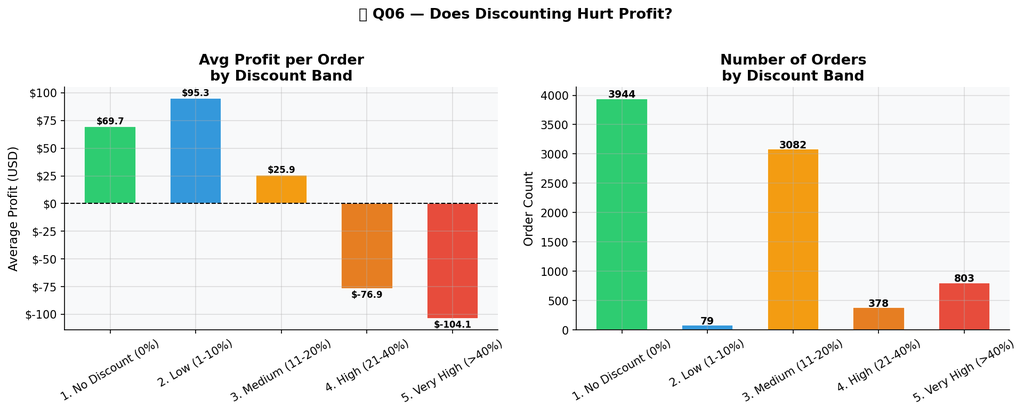

```
✅ Chart saved → reports/sql_q06_discount_impact.png
```

```python
# ── Q06: Discount Impact on Profit ────────────────────────────────────────────
# Business question: Are heavy discounts hurting our profitability?
# Concepts: CASE WHEN — SQL's if/else statement
# We bucket discount values into bands then compare avg profit per band
#
# CASE WHEN syntax:
#   CASE
#     WHEN condition1 THEN result1
#     WHEN condition2 THEN result2
#     ELSE default_result
#   END

q06 = pd.read_sql("""
    SELECT
        CASE
            WHEN discount = 0         THEN '1. No Discount (0%)'
            WHEN discount <= 0.10     THEN '2. Low (1-10%)'
            WHEN discount <= 0.20     THEN '3. Medium (11-20%)'
            WHEN discount <= 0.40     THEN '4. High (21-40%)'
            ELSE                           '5. Very High (>40%)'
        END                               AS discount_band,
        COUNT(*)                          AS total_orders,
        ROUND(AVG(discount) * 100, 1)     AS avg_discount_pct,
        ROUND(AVG(sales), 2)              AS avg_sales,
        ROUND(AVG(profit), 2)             AS avg_profit,
        ROUND(SUM(profit), 2)             AS total_profit
    FROM   orders
    GROUP BY discount_band
    ORDER BY discount_band
""", conn)

print("=" * 70)
print("📊 Q06 — Discount Impact on Profit")
print("=" * 70)
print(q06.to_string(index=False))

# ── Visualise Q06 ─────────────────────────────────────────────────────────────
fig, axes = plt.subplots(1, 2, figsize=(13, 5))

band_colors = ['#2ecc71', '#3498db', '#f39c12', '#e67e22', '#e74c3c']

# Chart 1: Avg Profit by Discount Band
axes[0].bar(
    q06['discount_band'], q06['avg_profit'],
    color=band_colors, edgecolor='white',
    linewidth=0.8, width=0.6
)
axes[0].axhline(0, color='black', linewidth=1, linestyle='--')
for bar, val in zip(axes[0].patches, q06['avg_profit']):
    axes[0].text(
        bar.get_x() + bar.get_width() / 2,
        bar.get_height() + (2 if val >= 0 else -8),
        f'${val:,.1f}',
        ha='center', fontsize=8, fontweight='bold'
    )
axes[0].set_title('Avg Profit per Order\nby Discount Band',
                  fontweight='bold')
axes[0].set_ylabel('Average Profit (USD)')
axes[0].tick_params(axis='x', rotation=30)
axes[0].yaxis.set_major_formatter(
    mticker.FuncFormatter(lambda x, _: f'${x:,.0f}'))

# Chart 2: Order Count by Discount Band
axes[1].bar(
    q06['discount_band'], q06['total_orders'],
    color=band_colors, edgecolor='white',
    linewidth=0.8, width=0.6
)
for bar, val in zip(axes[1].patches, q06['total_orders']):
    axes[1].text(
        bar.get_x() + bar.get_width() / 2,
        bar.get_height() + 20,
        str(val),
        ha='center', fontsize=9, fontweight='bold'
    )
axes[1].set_title('Number of Orders\nby Discount Band',
                  fontweight='bold')
axes[1].set_ylabel('Order Count')
axes[1].tick_params(axis='x', rotation=30)

fig.suptitle('📊 Q06 — Does Discounting Hurt Profit?',
             fontsize=13, fontweight='bold', y=1.02)
plt.tight_layout()
plt.savefig('../reports/sql_q06_discount_impact.png',
            dpi=150, bbox_inches='tight')
plt.show()
print("✅ Chart saved → reports/sql_q06_discount_impact.png")
```

```
===========================================================================
📊 Q07 — Top 10 Customers by Revenue
===========================================================================
     customer_name     segment  region       rfm_segment  total_orders  total_sales  total_profit  avg_discount_pct
       Sean Miller Home Office   South ❌ Lost / Inactive             4     24516.60      -2012.33             26.40
      Tamara Chand   Corporate Central ❌ Lost / Inactive             4     19044.91       8978.76             10.90
      Raymond Buch    Consumer    East ❌ Lost / Inactive             5     15056.85       6969.86              4.00
     Adrian Barton    Consumer    West ❌ Lost / Inactive            10     14473.57       5444.81             24.00
      Sanjit Chand    Consumer    West ❌ Lost / Inactive             8     14012.77       5781.71              5.70
      Tom Ashbrook Home Office    East ❌ Lost / Inactive             3     13807.77       4523.36             13.30
      Hunter Lopez    Consumer Central ❌ Lost / Inactive             5     12838.51       5611.64              2.00
      Ken Lonsdale    Consumer Central ❌ Lost / Inactive            10     12488.86        487.04             23.80
Christopher Conant    Consumer   South ❌ Lost / Inactive             5     12129.07       2177.05             28.20
      Becky Martin    Consumer Central ❌ Lost / Inactive             3     11432.84      -1759.86             18.00
```

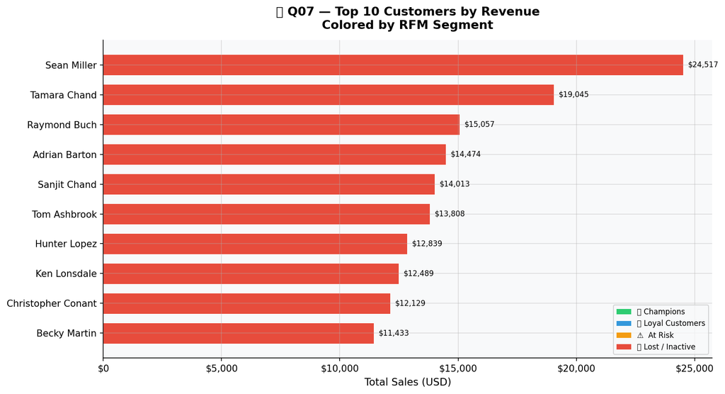

```
✅ Chart saved → reports/sql_q07_top_customers.png
```

```python
# ── Q07: Top 10 Customers by Revenue ──────────────────────────────────────────
# Business question: Who are our most valuable customers?
# Concepts: JOIN three tables, GROUP BY, ORDER BY, LIMIT
# We join orders → customers → rfm_segments to get segment labels
# LEFT JOIN rfm_segments — not all customers may have RFM scores
# so LEFT JOIN keeps all customers even if no RFM match

q07 = pd.read_sql("""
    SELECT
        c.customer_name,
        c.segment,
        c.region,
        r.segment                        AS rfm_segment,
        COUNT(DISTINCT o.order_id)       AS total_orders,
        ROUND(SUM(o.sales),   2)         AS total_sales,
        ROUND(SUM(o.profit),  2)         AS total_profit,
        ROUND(AVG(o.discount) * 100, 1)  AS avg_discount_pct
    FROM       orders        o
    JOIN       customers     c ON o.customer_id = c.customer_id
    LEFT JOIN  rfm_segments  r ON o.customer_id = r.customer_id
    GROUP BY   c.customer_id
    ORDER BY   total_sales DESC
    LIMIT 10
""", conn)

print("=" * 75)
print("📊 Q07 — Top 10 Customers by Revenue")
print("=" * 75)
print(q07.to_string(index=False))

# ── Visualise Q07 ─────────────────────────────────────────────────────────────
fig, ax = plt.subplots(figsize=(11, 6))

rfm_colors = {
    '🏆 Champions'      : '#2ecc71',
    '💛 Loyal Customers': '#3498db',
    '⚠️  At Risk'       : '#f39c12',
    '❌ Lost / Inactive': '#e74c3c'
}
bar_colors = [
    rfm_colors.get(seg, '#95a5a6')
    for seg in q07['rfm_segment']
]

ax.barh(
    q07['customer_name'][::-1],
    q07['total_sales'][::-1],
    color=bar_colors[::-1],
    edgecolor='white', linewidth=0.5,
    height=0.7
)

for bar, val in zip(ax.patches, q07['total_sales'][::-1]):
    ax.text(
        bar.get_width() + 200,
        bar.get_y() + bar.get_height() / 2,
        f'${val:,.0f}',
        va='center', fontsize=8
    )

from matplotlib.patches import Patch
legend_elements = [
    Patch(facecolor=c, label=s)
    for s, c in rfm_colors.items()
]
ax.legend(handles=legend_elements, fontsize=8,
          loc='lower right')

ax.set_title('📊 Q07 — Top 10 Customers by Revenue\n'
             'Colored by RFM Segment',
             fontweight='bold', pad=12)
ax.set_xlabel('Total Sales (USD)')
ax.xaxis.set_major_formatter(
    mticker.FuncFormatter(lambda x, _: f'${x:,.0f}'))
plt.tight_layout()
plt.savefig('../reports/sql_q07_top_customers.png',
            dpi=150, bbox_inches='tight')
plt.show()
print("✅ Chart saved → reports/sql_q07_top_customers.png")
```

```
======================================================================
📊 Q08 — Shipping Mode Performance
======================================================================
     ship_mode  total_orders  avg_ship_days  total_sales  total_profit  avg_profit_per_line  profit_margin_pct
Standard Class          2346          52.80   1103292.37     141174.90                29.85              12.80
  Second Class           804          36.30    388914.84      48633.48                29.69              12.50
   First Class           706          26.30    319059.37      43820.05                31.82              13.73
      Same Day           263           0.90    128133.04      15877.38                29.35              12.39
```

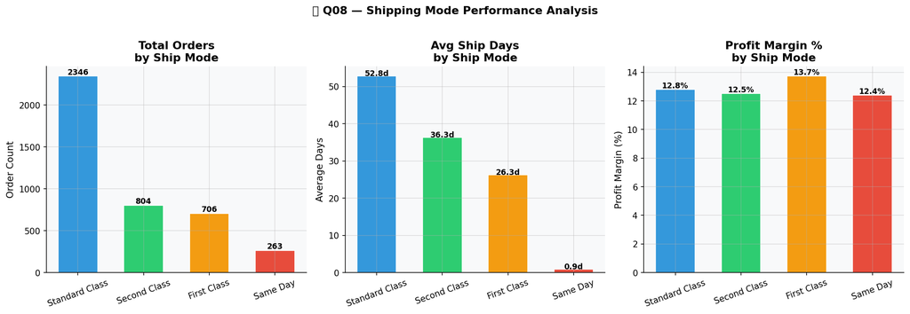

```
✅ Chart saved → reports/sql_q08_shipping_performance.png
```

```python
# ── Q08: Shipping Mode Performance ────────────────────────────────────────────
# Business question: Which shipping mode is most used and most profitable?
# Concepts: GROUP BY, AVG, COUNT, ROUND
# We analyse both financial and operational metrics per ship mode

q08 = pd.read_sql("""
    SELECT
        ship_mode,
        COUNT(DISTINCT order_id)          AS total_orders,
        ROUND(AVG(ship_days), 1)          AS avg_ship_days,
        ROUND(SUM(sales), 2)              AS total_sales,
        ROUND(SUM(profit), 2)             AS total_profit,
        ROUND(AVG(profit), 2)             AS avg_profit_per_line,
        ROUND(SUM(profit) /
              SUM(sales) * 100, 2)        AS profit_margin_pct
    FROM   orders
    GROUP BY ship_mode
    ORDER BY total_orders DESC
""", conn)

print("=" * 70)
print("📊 Q08 — Shipping Mode Performance")
print("=" * 70)
print(q08.to_string(index=False))

# ── Visualise Q08 ─────────────────────────────────────────────────────────────
fig, axes = plt.subplots(1, 3, figsize=(15, 5))

ship_colors = ['#3498db', '#2ecc71', '#f39c12', '#e74c3c']

# Chart 1: Total Orders by Ship Mode
axes[0].bar(
    q08['ship_mode'], q08['total_orders'],
    color=ship_colors, edgecolor='white',
    linewidth=0.8, width=0.6
)
for bar, val in zip(axes[0].patches, q08['total_orders']):
    axes[0].text(
        bar.get_x() + bar.get_width() / 2,
        bar.get_height() + 20,
        str(val), ha='center',
        fontsize=9, fontweight='bold'
    )
axes[0].set_title('Total Orders\nby Ship Mode', fontweight='bold')
axes[0].set_ylabel('Order Count')
axes[0].tick_params(axis='x', rotation=20)

# Chart 2: Avg Ship Days by Ship Mode
axes[1].bar(
    q08['ship_mode'], q08['avg_ship_days'],
    color=ship_colors, edgecolor='white',
    linewidth=0.8, width=0.6
)
for bar, val in zip(axes[1].patches, q08['avg_ship_days']):
    axes[1].text(
        bar.get_x() + bar.get_width() / 2,
        bar.get_height() + 0.05,
        f'{val:.1f}d', ha='center',
        fontsize=9, fontweight='bold'
    )
axes[1].set_title('Avg Ship Days\nby Ship Mode', fontweight='bold')
axes[1].set_ylabel('Average Days')
axes[1].tick_params(axis='x', rotation=20)

# Chart 3: Profit Margin by Ship Mode
axes[2].bar(
    q08['ship_mode'], q08['profit_margin_pct'],
    color=ship_colors, edgecolor='white',
    linewidth=0.8, width=0.6
)
for bar, val in zip(axes[2].patches, q08['profit_margin_pct']):
    axes[2].text(
        bar.get_x() + bar.get_width() / 2,
        bar.get_height() + 0.1,
        f'{val:.1f}%', ha='center',
        fontsize=9, fontweight='bold'
    )
axes[2].set_title('Profit Margin %\nby Ship Mode', fontweight='bold')
axes[2].set_ylabel('Profit Margin (%)')
axes[2].tick_params(axis='x', rotation=20)

fig.suptitle('📊 Q08 — Shipping Mode Performance Analysis',
             fontsize=13, fontweight='bold', y=1.02)
plt.tight_layout()
plt.savefig('../reports/sql_q08_shipping_performance.png',
            dpi=150, bbox_inches='tight')
plt.show()
print("✅ Chart saved → reports/sql_q08_shipping_performance.png")
```